# Reproducible Research: Peer Assessment 1

JM

2022-12-28

## Load libraries

```r
library(dplyr)
library(ggplot2)
library(tidyr)
library(lubridate)
library(knitr)
```

## Loading and preprocessing the data

Show any code that is needed to

1. Load the data (i.e. read.csv())
2. Process/transform the data (if necessary) into a format suitable for your analysis

Answer:

```r
setwd("C:/R/Coursera")

df<-read.csv("activity.csv")
```

## What is mean total number of steps taken per day?

For this part of the assignment, you can ignore the missing values in the dataset.

1. Calculate the total number of steps taken per day Answer:

```r
df2<-na.omit(df)

dfagg<-aggregate(df2["steps"], by=df2["date"], sum)

kable(dfagg)
```

| date | steps |
| --- | --- |
| 2012-10-02 | 126 |
| 2012-10-03 | 11352 |
| 2012-10-04 | 12116 |
| 2012-10-05 | 13294 |
| 2012-10-06 | 15420 |
| 2012-10-07 | 11015 |
| 2012-10-09 | 12811 |
| 2012-10-10 | 9900 |
| 2012-10-11 | 10304 |
| 2012-10-12 | 17382 |
| 2012-10-13 | 12426 |
| 2012-10-14 | 15098 |
| 2012-10-15 | 10139 |
| 2012-10-16 | 15084 |
| 2012-10-17 | 13452 |
| 2012-10-18 | 10056 |
| 2012-10-19 | 11829 |
| 2012-10-20 | 10395 |
| 2012-10-21 | 8821 |
| 2012-10-22 | 13460 |
| 2012-10-23 | 8918 |
| 2012-10-24 | 8355 |
| 2012-10-25 | 2492 |
| 2012-10-26 | 6778 |
| 2012-10-27 | 10119 |
| 2012-10-28 | 11458 |
| 2012-10-29 | 5018 |
| 2012-10-30 | 9819 |
| 2012-10-31 | 15414 |
| 2012-11-02 | 10600 |
| 2012-11-03 | 10571 |
| 2012-11-05 | 10439 |
| 2012-11-06 | 8334 |
| 2012-11-07 | 12883 |
| 2012-11-08 | 3219 |
| 2012-11-11 | 12608 |
| 2012-11-12 | 10765 |
| 2012-11-13 | 7336 |
| 2012-11-15 | 41 |
| 2012-11-16 | 5441 |
| 2012-11-17 | 14339 |
| 2012-11-18 | 15110 |
| 2012-11-19 | 8841 |
| 2012-11-20 | 4472 |
| 2012-11-21 | 12787 |
| 2012-11-22 | 20427 |
| 2012-11-23 | 21194 |
| 2012-11-24 | 14478 |
| 2012-11-25 | 11834 |
| 2012-11-26 | 11162 |
| 2012-11-27 | 13646 |
| 2012-11-28 | 10183 |
| 2012-11-29 | 7047 |

2. If you do not understand the difference between a histogram and a barplot, research the difference between them. Make a histogram of the total number of steps taken each day Answer:

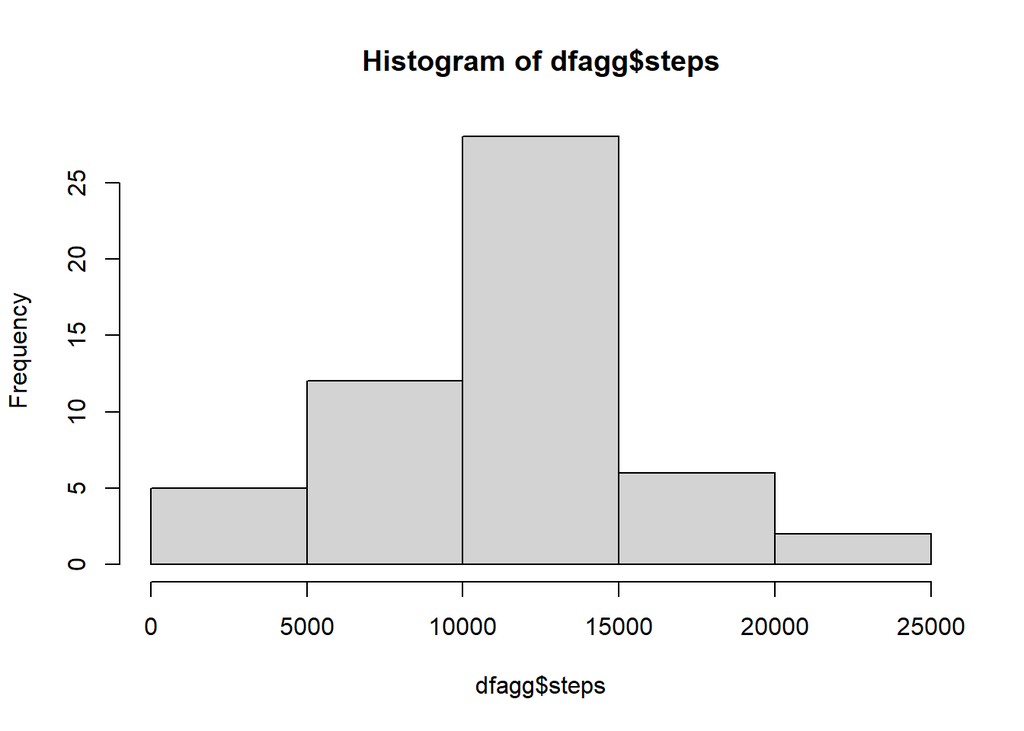

```r
hist(dfagg$steps)
```

3. Calculate and report the mean and median of the total number of steps taken per day Mean = 10766 Median = 10765

Answer:

```r
summary(dfagg$steps)
```

```
##    Min. 1st Qu.  Median    Mean 3rd Qu.    Max.
##      41    8841   10765   10766   13294   21194
```

## What is the average daily activity pattern?

1. Make a time series plot (i.e. type = “l”) of the 5-minute interval (x-axis) and the average number of steps taken, averaged across all days (y-axis) Answer:

```r
dfaggint<-aggregate(df2["steps"], by=df2["interval"], mean)

summary(dfaggint)
```

```
##     interval          steps
##  Min.   :   0.0   Min.   :  0.000
##  1st Qu.: 588.8   1st Qu.:  2.486
##  Median :1177.5   Median : 34.113
##  Mean   :1177.5   Mean   : 37.383
##  3rd Qu.:1766.2   3rd Qu.: 52.835
##  Max.   :2355.0   Max.   :206.170
```

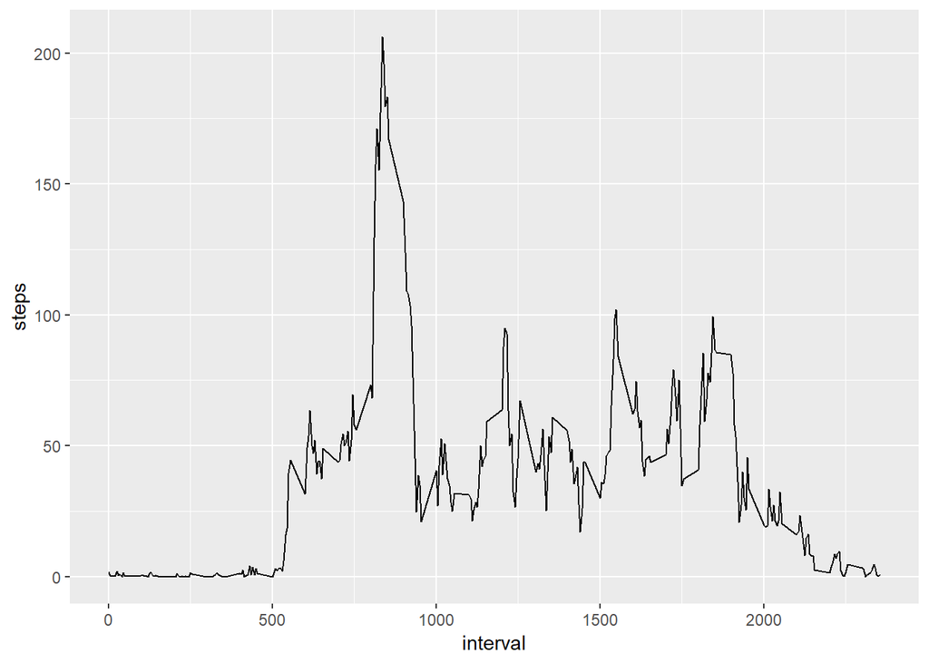

```r
pts<-ggplot(dfaggint,aes(x=interval, y = steps))+geom_line()

pts
```

2. Which 5-minute interval, on average across all the days in the dataset, contains the maximum number of steps? Answer:

```r
which(dfaggint$steps >= 206)
```

```
## [1] 104
```

```r
dfaggint$interval[which(dfaggint$steps >= 206)]
```

```
## [1] 835
```

## Inputing missing values

Note that there are a number of days/intervals where there are missing values (coded as NA). The presence of missing days may introduce bias into some calculations or summaries of the data.

1. Calculate and report the total number of missing values in the dataset (i.e. the total number of rows with NAs) Answer:

```r
length(is.na(df))
```

```
## [1] 52704
```

2. Devise a strategy for filling in all of the missing values in the dataset. The strategy does not need to be sophisticated. For example, you could use the mean/median for that day, or the mean for that 5-minute interval, etc.
3. Create a new dataset that is equal to the original dataset but with the missing data filled in. Answer for 2 and 3:

```r
NA2mean <-function(df) replace(df, is.na(df), mean(df, na.rm = T))

dfnarep<-replace(df,T,lapply(df,NA2mean))
dfaggnanmean<-aggregate(dfnarep["steps"], by=dfnarep["date"], mean)

dfaggnanmedian<-aggregate(dfnarep["steps"], by=dfnarep["date"], median)
```

```r
summary(df)
```

```
##      steps            date              interval
##  Min.   :  0.00   Length:17568       Min.   :   0.0
##  1st Qu.:  0.00   Class :character   1st Qu.: 588.8
##  Median :  0.00   Mode  :character   Median :1177.5
##  Mean   : 37.38                      Mean   :1177.5
##  3rd Qu.: 12.00                      3rd Qu.:1766.2
##  Max.   :806.00                      Max.   :2355.0
##  NA's   :2304
```

```r
summary(dfaggnanmean)
```

```
##      date               steps
##  Length:61          Min.   : 0.1424
##  Class :character   1st Qu.:34.0938
##  Mode  :character   Median :37.3826
##                     Mean   :37.3826
##                     3rd Qu.:44.4826
##                     Max.   :73.5903
```

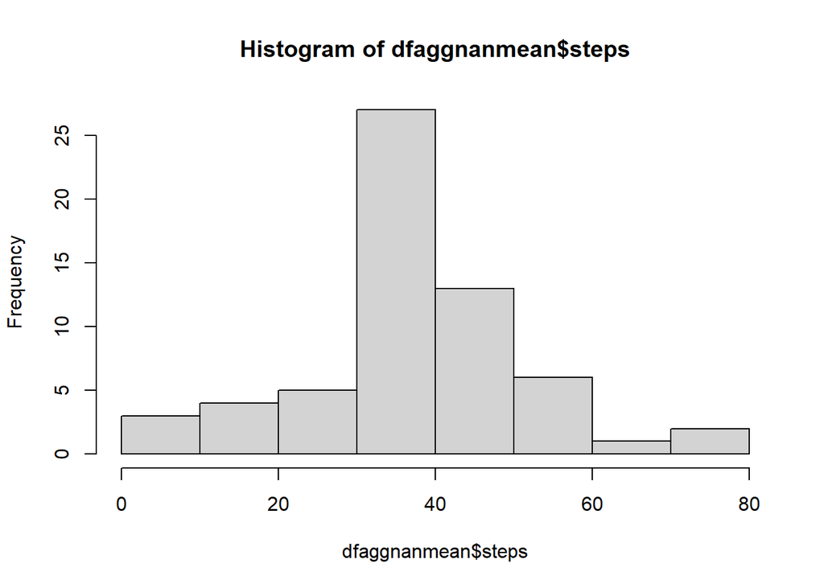

```r
hist(dfaggnanmean$steps)
```

## Are there differences in activity patterns between weekdays and weekends?

For this part the weekdays() function may be of some help here. Use the dataset with the filled-in missing values for this part.

1. Create a new factor variable in the dataset with two levels – “weekday” and “weekend” indicating whether a given date is a weekday or weekend day. Answer:

```r
dfnarep$date <- as.Date(dfnarep$date)
weekdays1<- c('Monday','Tuesday','Wednesday','Thursday','Friday')

dfnarep$wDay <- factor((weekdays(dfnarep$date)  %in%  weekdays1), levels = c(FALSE,TRUE), labels = c('weekend','weekday'))

glimpse(dfnarep)
```

```
## Rows: 17,568
## Columns: 4
## $ steps    <dbl> 37.3826, 37.3826, 37.3826, 37.3826, 37.3826, 37.3826, 37.3826, 37.3826, 37.3826, 37.3826, 37.3826, 3…
## $ date     <date> 2012-10-01, 2012-10-01, 2012-10-01, 2012-10-01, 2012-10-01, 2012-10-01, 2012-10-01, 2012-10-01, 201…
## $ interval <dbl> 0, 5, 10, 15, 20, 25, 30, 35, 40, 45, 50, 55, 100, 105, 110, 115, 120, 125, 130, 135, 140, 145, 150,…
## $ wDay     <fct> weekday, weekday, weekday, weekday, weekday, weekday, weekday, weekday, weekday, weekday, weekday, w…
```

```r
X<-split(dfnarep,dfnarep$wDay)

Xwy<-X$weekday
Xwd<-X$weekend

xwymean<-aggregate(Xwy["steps"], by=Xwy["interval"], mean)

xwdmean<-aggregate(Xwd["steps"], by=Xwd["interval"], mean)
```

2. Make a panel plot containing a time series plot (i.e. type = “l”) of the 5-minute interval (x-axis) and the average number of steps taken, averaged across all weekday days or weekend days (y-axis). See the README file in the GitHub repository to see an example of what this plot should look like using simulated data. Answer:

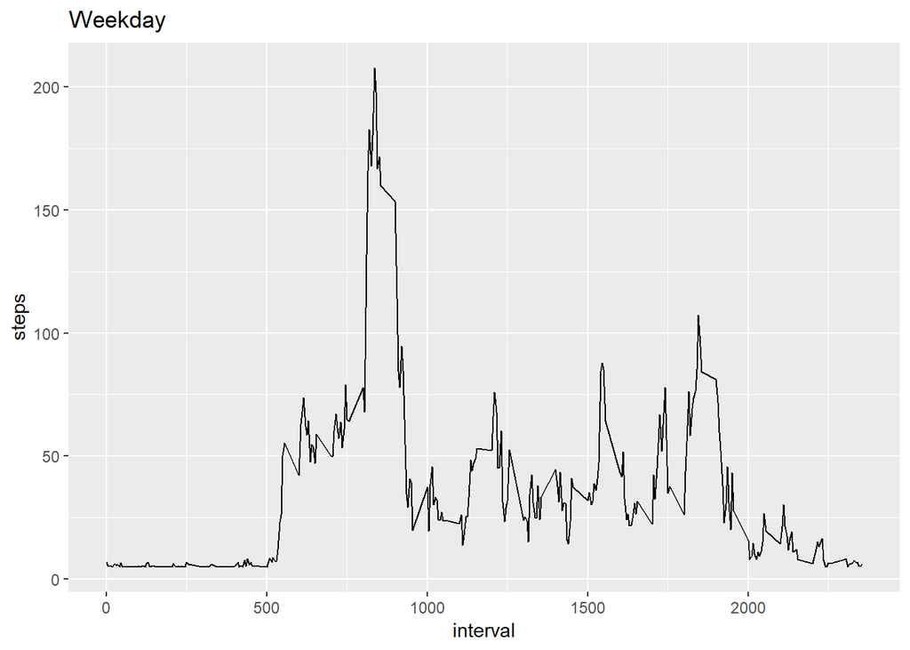

```r
ptswy<-ggplot(xwymean,aes(x=interval, y = steps, group=1))+geom_line()+ggtitle("Weekday")

ptswy
```

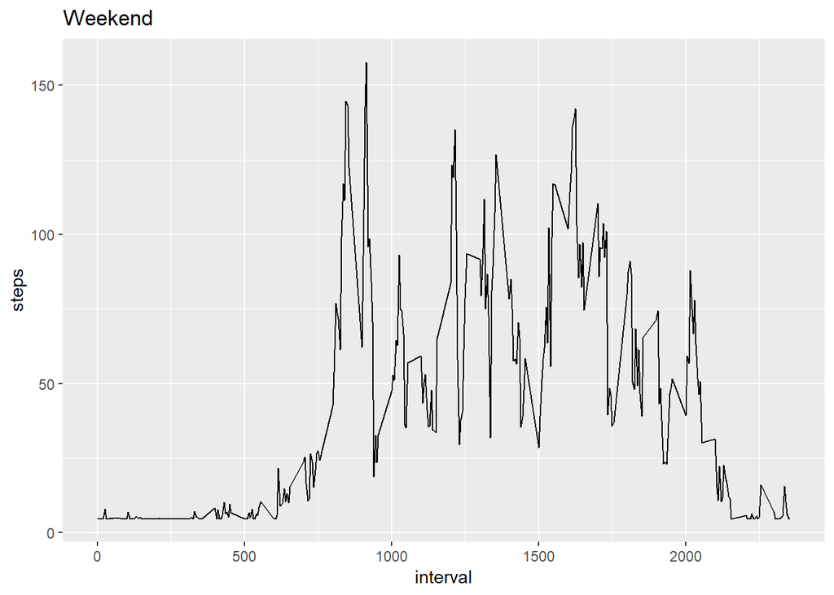

```r
ptswd<-ggplot(xwdmean,aes(x=interval, y = steps, group=1))+geom_line()+ggtitle("Weekend")

ptswd
```